# Problem Statement:

There is mall in specific city that contains information about the customer who are subcribed to the card, they provided their details like annual income, age and gender. The spending scores are obtained by matching with the customer ID and with the customer income with the amount of money they spend in the mall and number of times they visit per week, the values takes between 1 and 100

Mall management need to segement their clients into different segements based on the matrics 1. Annual Income and 2. Spending scores. Management has no idea about the client's segments and even has no idea about the how many segments there would be.

# Solution:

Thus this is typically a clustering problem since we can't predict the outcome, so we need to use unsupervised algorithm. Best and easy algorithm are K-Means clustering algorithm

## Applying the K-means to the datasets

```python
import pandas as pd #used for Importing and managing datasets
import numpy as np # Used for mathematical calculation
import matplotlib.pyplot as plt # Used for Ploting the charts
import seaborn as sns # Usning for ploting using Seaborn
import warnings; # Just to ignore warnings
warnings.simplefilter('ignore')
```

## Importing data using pandas

```python
c= pd.read_csv('F:\pythonProject\Vignesh Programming\Clustering\KMeans\Mall_Customers.csv')
c.describe()
```

|  | CustomerID | Age | Annual Income (k$) | Spending Score (1-100) |
| --- | --- | --- | --- | --- |
| count | 200.000000 | 200.000000 | 200.000000 | 200.000000 |
| mean | 100.500000 | 38.850000 | 60.560000 | 50.200000 |
| std | 57.879185 | 13.969007 | 26.264721 | 25.823522 |
| min | 1.000000 | 18.000000 | 15.000000 | 1.000000 |
| 25% | 50.750000 | 28.750000 | 41.500000 | 34.750000 |
| 50% | 100.500000 | 36.000000 | 61.500000 | 50.000000 |
| 75% | 150.250000 | 49.000000 | 78.000000 | 73.000000 |
| max | 200.000000 | 70.000000 | 137.000000 | 99.000000 |

```python
c.head()
```

|  | CustomerID | Genre | Age | Annual Income (k$) | Spending Score (1-100) |
| --- | --- | --- | --- | --- | --- |
| 0 | 1 | Male | 19 | 15 | 39 |
| 1 | 2 | Male | 21 | 15 | 81 |
| 2 | 3 | Female | 20 | 16 | 6 |
| 3 | 4 | Female | 23 | 16 | 77 |
| 4 | 5 | Female | 31 | 17 | 40 |

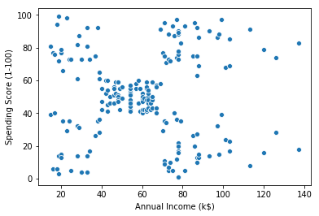

```python
sns.scatterplot('Annual Income (k$)','Spending Score (1-100)',data=c)
```

## Fetching inputs : Annual Income and Spending score

```python
X= c.iloc[:,[3,4]].values
```

## Using Elbow Method to get optimal Clusters(K) value

```python
from sklearn.cluster import KMeans
```

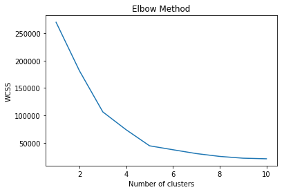

```python
#By using WCSS we are going to iterate for 10 values
wcss=[]
for i in range(1,11):
    #init- Initialization method for choosing centeroids by using K-Means++ method
    #max_iter- Is the maximun number of iteration for finding the final clusters to default 300
    #n_init- # of times the iterations should take place with different centeroids
    #randon_state- Fixes all random factors of Kmeans process so when we set to 0 we will get same results
    kmeans= KMeans(n_clusters=i,init='k-means++',max_iter=300, n_init=10,random_state=0)
    kmeans.fit(X)
    #inertia- is used for math calculation like sum of squares
    wcss.append(kmeans.inertia_)
#Ploting the Elbow method
plt.plot(range(1,11),wcss)
plt.title('Elbow Method')
plt.xlabel("Number of clusters")
plt.ylabel("WCSS")
plt.show()
```

## Applying the K-means to the datasets

Thus from the graph we can able to get the number of clusters as 5

```python
kmeans= KMeans(5,init='k-means++',max_iter=300, n_init=10,random_state=0)
#predict is used to observe which cluster groups clients belongs to
y=kmeans.fit_predict(X)
y
```

```
array([4, 3, 4, 3, 4, 3, 4, 3, 4, 3, 4, 3, 4, 3, 4, 3, 4, 3, 4, 3, 4, 3,
       4, 3, 4, 3, 4, 3, 4, 3, 4, 3, 4, 3, 4, 3, 4, 3, 4, 3, 4, 3, 4, 1,
       4, 3, 1, 1, 1, 1, 1, 1, 1, 1, 1, 1, 1, 1, 1, 1, 1, 1, 1, 1, 1, 1,
       1, 1, 1, 1, 1, 1, 1, 1, 1, 1, 1, 1, 1, 1, 1, 1, 1, 1, 1, 1, 1, 1,
       1, 1, 1, 1, 1, 1, 1, 1, 1, 1, 1, 1, 1, 1, 1, 1, 1, 1, 1, 1, 1, 1,
       1, 1, 1, 1, 1, 1, 1, 1, 1, 1, 1, 1, 1, 2, 0, 2, 1, 2, 0, 2, 0, 2,
       1, 2, 0, 2, 0, 2, 0, 2, 0, 2, 1, 2, 0, 2, 0, 2, 0, 2, 0, 2, 0, 2,
       0, 2, 0, 2, 0, 2, 0, 2, 0, 2, 0, 2, 0, 2, 0, 2, 0, 2, 0, 2, 0, 2,
       0, 2, 0, 2, 0, 2, 0, 2, 0, 2, 0, 2, 0, 2, 0, 2, 0, 2, 0, 2, 0, 2,
       0, 2])
```

```python
# Finding Centeroids
kmeans.cluster_centers_
```

```
array([[88.2       , 17.11428571],
       [55.2962963 , 49.51851852],
       [86.53846154, 82.12820513],
       [25.72727273, 79.36363636],
       [26.30434783, 20.91304348]])
```

```python
#Creating a new dataframe x for visualization purpose
x= c[['CustomerID','Age','Annual Income (k$)','Spending Score (1-100)']]
x['cluster(k=5)']=y
x.head()
```

|  | CustomerID | Age | Annual Income (k$) | Spending Score (1-100) | cluster(k=5) |
| --- | --- | --- | --- | --- | --- |
| 0 | 1 | 19 | 15 | 39 | 4 |
| 1 | 2 | 21 | 15 | 81 | 3 |
| 2 | 3 | 20 | 16 | 6 | 4 |
| 3 | 4 | 23 | 16 | 77 | 3 |
| 4 | 5 | 31 | 17 | 40 | 4 |

## Visualization

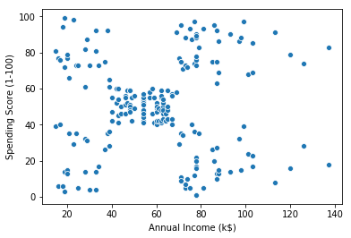

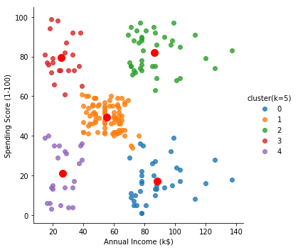

```python
# Visualising the clusters
sns.scatterplot('Annual Income (k$)','Spending Score (1-100)',data=x)
sns.lmplot('Annual Income (k$)','Spending Score (1-100)',data=x,fit_reg=False,hue="cluster(k=5)")
plt.scatter(kmeans.cluster_centers_[:,0],kmeans.cluster_centers_[:,1],c='red',s=100)
```

```python
#Exporting the data for client reference
x.to_csv('F:\pythonProject\Vignesh Programming\Clustering\KMeans\Mall_Customers_ClusterDetails.csv',index=0)
```

```
                                                                                                           Vignesh CS
```